# Warm-up challenges for week 4

Now that we've seen how to clean in Pandas, it's time for you to apply this knowledge. This week has three preparatory challenges. Make sure to give it a try and complete all of them.

Each challenge has two components:

1. **Programming and interpretation**
2. **Reflection**

**Some important notes for the challenges:**

1. These challenges are a warming up, and help you get ready for class. Make sure to give them a try on all of them.
2. If you get an error message, try to troubleshoot it (using Google often helps). If all else fails, go to the next challenge (but make sure to give it a try).
3. These challenges are ungraded, yet they help you prepare for the graded challenges in the portfolio. If you want to be efficient, have a look at what you need to do for the upcoming graded challenges and see how to combine the work.

### Facing issues?

We are constantly monitoring the issues on the GitHub to help you out. Don't hesitate to log an issue there, explaining well what the problem is, showing the code you are using, and the error message you may be receiving.

**Important:** We are only monitoring the repository in weekdays, from 9.30 to 17.00. Issues logged after this time will most likely be answered the next day.

### Using Markdown

1. Make sure to combine code *and* markdown to answer all questions. Mention specifically the question (and question number) and the answer in markdown, relating to the code and the output of the code. For the graded challenges, failing to do so will impact the grade, as we will not be able to see whether you answered the question.
2. For every line of code, please include a cell in MarkDown explaining what the code is expected to do.

## Getting setup for the challenges

We will use actual Twitter data for the challenges of this week. To do so, you need:

- Twitter data you have collected using twarc. Please use **the same data** that you requested sentiment analysis for
- The sentiment analysis results (get them from OneDrive)

*You can therefore the code you created for the DA3 challenges where you merged your Twitter data with the sentiment data and created a meaningful sentiment measure, and just continue from there. If you have not completed DA3, make sure to perfom these steps for this assignment*.

**All the challenges below are with this Twitter data. Make sure to start your challenge by doing the basics of loading and inspecting the data, even if not specified in challenge itself.**

## Challenge 1

In the tutorial of last week, we created a categorical variable using conditions. This week, we have seen how to create binary variables based on text applying simple Natural Language Processing and how to "recode" variables using conditions.

### Programming challenge

For this challenge, create two variables for the Twitter data based on the text column. They should be two **meaningful** categories for your data, and they can either be binary taking the value 0 (when the tweet is not of that category) or 1 (when the tweet is of that category) or categorical with multiple meaningful categories that a tweet can fall under.

Make sure to explain (in MarkDown) what these variables are, and provide some descriptives when they are done.

### Reflection

When using digital analytics to answer questions and solve problems, multiple decisions have to be made at different stages of the project that may result in bias. This also applies to data collection and pre-processing. When collecting data, choices made can introduce bias into the data. Data pre-processing, including creating categories can also be an additional source of bias. In fact, using Natural Language Processing for categorization of cases in our dataset (e.g., for categorizing tweets), we can reduce the complexity of the dataset and get a better picture of our data, but also introduce more layers of bias into it.

Building on the layers of bias described by Eckhouse et al. (2019), reflect on the types of bias possibly introduced to your dataset due to choices made 1) when collecting twitter data 2) when creating categories it in this challenge.

Please make sure to motivate your response, and provide specific examples

For challange one, I need:

- categorical variable created based on text - Tweets that mention digital media tech companies (Apple, Google, Facebook) - my wordlist: `["apple", "google", "facebook"]`
- categorical variable created based on text - Tweets that mention EU or US

```python
import pandas as pd
import seaborn as sns
pd.set_option('display.float_format', lambda x: '%.3f' % x)
%matplotlib inline
```

```python
df = pd.read_pickle('tweets_sent.pkl')
```

### Data exploration

```python
df.head(20)
```

|  | id | text | metric_retweet_count | metric_followers_count | metric_like_count | pseudID | positive | negative | neutral |
| --- | --- | --- | --- | --- | --- | --- | --- | --- | --- |
| 0 | 1438405322603999239 | RT @mention .@mention is trying to skirt human... | 118 | 21 | 0 | 1 | 1 | -1 | 0 |
| 1 | 1438405320204853248 | “conspiracy practices —the methods by which tr... | 0 | 879 | 0 | 2 | 2 | -2 | -1 |
| 2 | 1438405307693027328 | @mention Have you done any work to estimate th... | 0 | 230 | 0 | 3 | 1 | -1 | 0 |
| 3 | 1438405226801807364 | 📝We have examined the design, implementation a... | 0 | 12992 | 0 | 5 | 2 | -3 | -1 |
| 4 | 1438405184544067589 | first time trying out the #sarkargame. and, it... | 0 | 197 | 0 | 6 | 2 | -4 | -1 |
| 5 | 1438405167460749316 | RT @mention We wanted flying cars. Instead we ... | 256 | 284 | 0 | 7 | 1 | -1 | 0 |
| 6 | 1438405155976843268 | RT @mention "Remember when Facebook CEO Mark Z... | 861 | 229 | 0 | 8 | 2 | -1 | 1 |
| 7 | 1438404986283646978 | RT @mention The US-led war on terror, in the g... | 34 | 16529 | 0 | 11 | 1 | -4 | -1 |
| 8 | 1438404982278004738 | RT @mention Modi govt’s refusal to submit an a... | 160 | 8 | 0 | 12 | 1 | -2 | -1 |
| 9 | 1438404913642577928 | RT @mention 📢#OUTNOW \| @mention and @mention g... | 3 | 191 | 0 | 13 | 1 | -1 | 0 |
| 10 | 1438404847406100481 | We're set up and ready here at @mention #OPSEC... | 0 | 2418 | 0 | 15 | 2 | -1 | 1 |
| 11 | 1438404839114002435 | Critics condemn the UK’s increasingly privatis... | 0 | 3869 | 0 | 16 | 2 | -2 | -1 |
| 12 | 1438404827499872261 | The EuFMD, @mention @mention &amp; @mention wi... | 0 | 2612 | 0 | 17 | 2 | -3 | -1 |
| 13 | 1438404825700610048 | Learn about our 10 year relationship with Affi... | 0 | 69 | 0 | 18 | 1 | -1 | 0 |
| 14 | 1438404822848327683 | RT @mention 'Spyware like Pegasus is incompati... | 12 | 118 | 0 | 19 | 2 | -3 | -1 |
| 15 | 1438404785628139525 | RT @mention The plans being currently being la... | 84 | 14 | 0 | 21 | 1 | -2 | -1 |
| 16 | 1438404715360837632 | RT @mention In Connecticut, The New "Permanent... | 51 | 177 | 0 | 22 | 1 | -1 | 0 |
| 17 | 1438404708096434181 | @mention @mention @mention @mention @mention M... | 0 | 66 | 0 | 23 | 1 | -1 | 0 |
| 18 | 1438404705206472707 | Telenor company’s asia head told that they had... | 0 | 206 | 0 | 24 | 1 | -2 | -1 |
| 19 | 1438404691860262913 | RT @mention Don’t forget about influenza…\n\nL... | 1 | 1080 | 0 | 25 | 1 | -1 | 0 |

```python
df.columns
```

```
Index(['id', 'text', 'metric_retweet_count', 'metric_followers_count',
       'metric_like_count', 'pseudID', 'positive', 'negative', 'neutral'],
      dtype='object')
```

```python
df.dtypes
```

```
id                         int64
text                      object
metric_retweet_count       int64
metric_followers_count     int64
metric_like_count          int64
pseudID                   object
positive                  object
negative                  object
neutral                   object
dtype: object
```

Question: what to do with retweets?

Let's check how many I have

```python
def is_rt(text):
    text = text.split()
    if text[0] == 'RT':
        return 1
    return 0
```

```python
df['is_retweet'] = df['text'].apply(is_rt)
```

```python
df[['text', 'is_retweet']].head(10)
```

|  | text | is_retweet |
| --- | --- | --- |
| 0 | RT @mention .@mention is trying to skirt human... | 1 |
| 1 | “conspiracy practices —the methods by which tr... | 0 |
| 2 | @mention Have you done any work to estimate th... | 0 |
| 3 | 📝We have examined the design, implementation a... | 0 |
| 4 | first time trying out the #sarkargame. and, it... | 0 |
| 5 | RT @mention We wanted flying cars. Instead we ... | 1 |
| 6 | RT @mention "Remember when Facebook CEO Mark Z... | 1 |
| 7 | RT @mention The US-led war on terror, in the g... | 1 |
| 8 | RT @mention Modi govt’s refusal to submit an a... | 1 |
| 9 | RT @mention 📢#OUTNOW \| @mention and @mention g... | 1 |

```python
df['is_retweet'].value_counts(normalize=True)
```

```
1   0.722
0   0.278
Name: is_retweet, dtype: float64
```

```python
df['text'].value_counts()
```

```
RT @mention BIG NEWS: Do you own an Apple product? UPDATE IT NOW. New zero-click NSO Group #Pegasus spyware has been infecting iPho…                                                                                                                                                                        …
RT @mention As someone who has just got through Covid-19, I wondered how rare I am to have contracted it as a double vaxxed person. Accordi…                                                                                                                                                                …
RT @mention The poem 'Dangerous Coats' by contemporary Irish writer Sharon Owens #WomensArt Home Office surveillance photograph of suff…                                                                                                                                                                    …
RT @mention George W. Bush, the man who brought us torture, indefinite detention, assassination, and mass surveillance, rebukes those who’…                                                                                                                                                                 …
RT @mention "Remember when Facebook CEO Mark Zuckerberg said "the future is private"? LOL." - @mention breaks down Facebook's l…                                                                                                                                                                            …
                                                                                                                                                                                                                                                                                                            …
They are also completely self-funded and have been around for over 25 years, and refuse to take venture capital. There is almost ZERO chance their data will end up in the hands of Big Tech, which makes the surveillance capitalists furious. 😂\n\n/3\n\nhttps://t.co/QwgDDDyrLy                          …
Are you still here? \n\nIrritate the toadies of surveillance capitalism even more: use my sure-to-be-labelled-as-grifter-affiliate-link 😀 and go and buy some Zoho software. They have more than 40+ apps. \n\n/6\n\nhttps://t.co/glIoDlA9Ow                                                                …
Part of me wants the FBI to set up surveillance to get the name of every single one of these Democracy hating traitors who comes to this anti-American rally.\n\nBut that is exactly what they want us to do &amp; that's not the America we voted to protect when we elected Biden President https://t.co/D…
@mention @mention @mention @mention @mention It's almost like people don't like the Federal Liberals or something. Are you under the impression that police make election sign surveillance a priotity?                                                                                                     …
RT @mention The camera issue is not a safeguards violation. IAEA inspectors continue to have access to all the facilities in Iran that t…                                                                                                                                                                   …
Name: text, Length: 21709, dtype: int64
```

```python
df_original = df[df['is_retweet']==0]
```

```python
len(df_original), len(df)
```

```
(16954, 60926)
```

I will continue with the original tweets

### Creating the categorical variable for digital media tech

```python
def wordlist_any_present(text, query):
    import re
    text = str(text).lower()
    newquery = []
    for word in query:
        newquery.append(str(word).lower())
    tokens = re.findall(r"[\w']+|[.,!?;$@#]", text)

    for word in newquery:
        if word in tokens:
            return 1
    return 0
```

```python
df_original['digi_media_tech'] = df_original['text'].apply(wordlist_any_present,
                                                       args=(['google', 'apple', 'facebook'],))
```

```python
df_original['digi_media_tech'].value_counts()
```

```
0    16497
1      457
Name: digi_media_tech, dtype: int64
```

```python
df['digi_media_tech'] = df['text'].apply(wordlist_any_present,
                                                       args=(['google', 'apple', 'facebook'],))
```

```python
df['digi_media_tech'].value_counts()
```

```
0    54439
1     6487
Name: digi_media_tech, dtype: int64
```

### Creating the categorical variable for country

```python
df_original['usa'] = df_original['text'].apply(wordlist_any_present,
                                                       args=(['us', 'usa'],))
```

```python
df_original['usa'].value_counts()
```

```
0    15958
1      996
Name: usa, dtype: int64
```

```python
df_original['eu'] = df_original['text'].apply(wordlist_any_present,
                                                       args=(['eu', 'europe'],))
```

```python
df_original['eu'].value_counts()
```

```
0    16365
1      589
Name: eu, dtype: int64
```

```python
def categorise_df(row):
    # Here I am creating a new column (called user_type) and giving it a default value (regular user)
    row['country'] = 'none'
    # I can put the conditions I want here
    if (row['usa'] == 1) and (row['eu'] == 0):
        row['country'] = 'usa'

    if (row['usa'] == 0) and (row['eu'] == 1):
        row['country'] = 'eu'

    if (row['usa'] == 1) and (row['eu'] == 1):
        row['country'] = 'both'

    # You can modify this function as much as you want (above), but it must always return the row
    return row
```

```python
df_original = df_original.apply(categorise_df, axis=1)
```

```python
df_original['country'].value_counts()
```

```
none    15384
usa       981
eu        574
both       15
Name: country, dtype: int64
```

### Exploration of my new variables

```python
df['digi_media_tech'].value_counts(normalize=True)
```

```
0   0.894
1   0.106
Name: digi_media_tech, dtype: float64
```

```python
df_original['country'].value_counts(normalize=True)
```

```
none   0.907
usa    0.058
eu     0.034
both   0.001
Name: country, dtype: float64
```

```python
df_original['digi_media_tech'].describe()
```

```
count   16954.000
mean        0.027
std         0.162
min         0.000
25%         0.000
50%         0.000
75%         0.000
max         1.000
Name: digi_media_tech, dtype: float64
```

## Challenge 2

### Programming challenge

Propose and visualise the answer for a RQ that has the **number of retweets** as the dependent variable, and one of the categories you created as the independent variable. Justify your choices in the answer.

In this answer, you need to:

- Show descriptive statistics for the IV and the DV
- Create one univariate visualisation for the IV
- Create one univariate visualisation for the DV
- Create one bivariate visualisation with the IV and DV in the same chart
- Show the descriptives of the DV grouped by the IV and interpret them

### Reflection

Visualisations are very helpful in exploring your dataset and relations between variables. They are also commonly used in reporting towards different stakeholders as a tool to make the data understandable to a wider audience. However, visualisations can also be very misleading. Looking at the visualisations discussed in the tutorial and the ones you have chosen in this challenge, reflect to what extent and in what way: 1) The choices you made could lead to manipulation or incorrect conclusions 2) How the usage of different charts or ways to visualize the data by others may lead to manipulation or incorrect conclusions

For both 1) and 2), make sure to provide specific examples and motivate your response.

### My research question:

To what extent is there a relation between the mention of digital media tech companies in a tweet and the engagement it generates?

- IV = mention of digital media tech
- DV = number of retweets
- Unit of analysis = an original tweet

```python
df_original[['digi_media_tech', 'metric_retweet_count']].head(10)
```

|  | digi_media_tech | metric_retweet_count |
| --- | --- | --- |
| 1 | 0 | 0 |
| 2 | 0 | 0 |
| 3 | 0 | 0 |
| 4 | 0 | 0 |
| 10 | 0 | 0 |
| 11 | 0 | 0 |
| 12 | 0 | 0 |
| 13 | 0 | 0 |
| 17 | 0 | 0 |
| 18 | 0 | 0 |

```python
df_original[['digi_media_tech', 'metric_retweet_count']].dtypes
```

```
digi_media_tech         int64
metric_retweet_count    int64
dtype: object
```

### Descriptive statistics

```python
df_original[['digi_media_tech', 'metric_retweet_count']].describe()
```

|  | digi_media_tech | metric_retweet_count |
| --- | --- | --- |
| count | 16954.000 | 16954.000 |
| mean | 0.027 | 2.701 |
| std | 0.162 | 39.627 |
| min | 0.000 | 0.000 |
| 25% | 0.000 | 0.000 |
| 50% | 0.000 | 0.000 |
| 75% | 0.000 | 0.000 |
| max | 1.000 | 4114.000 |

```python
df_original.groupby(['digi_media_tech'])['metric_retweet_count'].describe()
```

| digi_media_tech | count | mean | std | min | 25% | 50% | 75% | max |
| --- | --- | --- | --- | --- | --- | --- | --- | --- |
| 0 | 16497.000 | 2.362 | 22.821 | 0.000 | 0.000 | 0.000 | 0.000 | 1232.000 |
| 1 | 457.000 | 14.926 | 198.461 | 0.000 | 0.000 | 0.000 | 1.000 | 4114.000 |

### Univariate visualisations

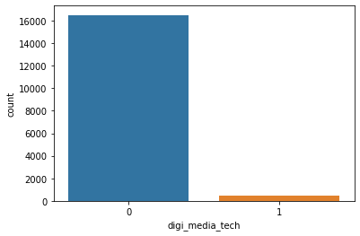

```python
# IV - binary
sns.countplot(x='digi_media_tech', data=df_original)
```

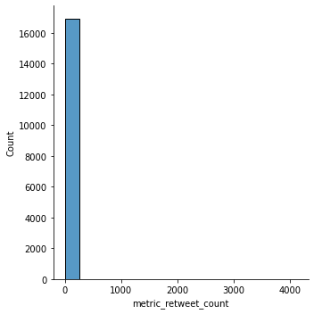

```python
#DV - continous
sns.displot(x = 'metric_retweet_count', data = df_original)
```

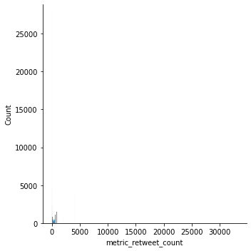

```python
#Out of curiosity - what happens when I take my original dataframe with retweets?
sns.displot(x = 'metric_retweet_count', data = df)
```

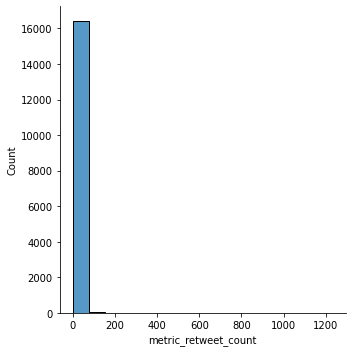

```python
sns.displot(x = 'metric_retweet_count', data = df_original[df_original['digi_media_tech']== 0])
```

[figure not shown]

```python
sns.displot(x = 'metric_retweet_count', data = df_original[df_original['digi_media_tech']== 1])
```

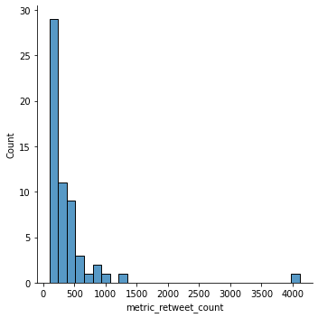

```python
sns.displot(x = 'metric_retweet_count', data = df_original[df_original['metric_retweet_count'] > 100])
```

### Bivariate visualisations

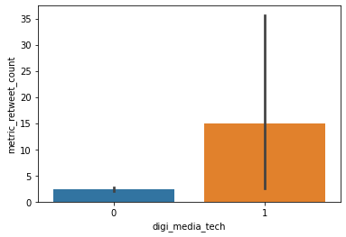

```python
# IV = binary, DV = continous
sns.barplot(x='digi_media_tech', y='metric_retweet_count', data=df_original)
```

## Challenge 3

### Programming challenge

Propose and visualise the answer for a RQ that has the **sentiment** as the dependent variable, and one of the categories you created as the independent variable. Justify your choices in the answer.

In this answer, you need to:

- Show descriptive statistics for the IV and the DV
- Create one univariate visualisation for the IV
- Create one univariate visualisation for the DV
- Create one bivariate visualisation with the IV and DV in the same chart
- Show the descriptives of the DV grouped by the IV and interpret them

### Reflection

Imagine that you proceed with the dataset you have created to answer your research question and help and organization. In the next step, you will conduct your analysis and create a model to automatically predict the user interests (topics) and their sentiment about the topic. These predictions will be later used to determine which type of advertisement the user will see.

Looking at privacy and ethical issues when working with data of individuals (even when it is pseudonymized), reflect how applying such frameworks as the DEDA aid could mitigate them when you use the data you have prepared and what issues remain.Please motivate your response, and provide specific ethical issues and how they can(not) be mitigated by such frameworks.

### My research question:

To what extent is there a relation between a mention of national context in the tweet and its sentiment?

- IV = mention of us, eu or both
- DV = sentiment
- Unit of analysis = an original tweet

### Data preparation

```python
df_original.columns
```

```
Index(['id', 'text', 'metric_retweet_count', 'metric_followers_count',
       'metric_like_count', 'pseudID', 'positive', 'negative', 'neutral',
       'is_retweet', 'digi_media_tech', 'usa', 'eu', 'country'],
      dtype='object')
```

```python
df_original[['country', 'positive', 'negative']].head(10)
```

|  | country | positive | negative |
| --- | --- | --- | --- |
| 1 | none | 2 | -2 |
| 2 | none | 1 | -1 |
| 3 | none | 2 | -3 |
| 4 | none | 2 | -4 |
| 10 | none | 2 | -1 |
| 11 | none | 2 | -2 |
| 12 | none | 2 | -3 |
| 13 | none | 1 | -1 |
| 17 | none | 1 | -1 |
| 18 | eu | 1 | -2 |

```python
df_original[['country', 'positive', 'negative']].dtypes
```

```
country     object
positive    object
negative    object
dtype: object
```

```python
df_original['positive'] = df_original['positive'].apply(pd.to_numeric)
```

```python
df_original['negative'] = df_original['negative'].apply(pd.to_numeric)
```

```python
df_original['overall_sent'] = df_original['negative'] + df_original['positive']
```

```python
df_original[['country', 'positive', 'negative', 'overall_sent']].head(10)
```

|  | country | positive | negative | overall_sent |
| --- | --- | --- | --- | --- |
| 1 | none | 2 | -2 | 0 |
| 2 | none | 1 | -1 | 0 |
| 3 | none | 2 | -3 | -1 |
| 4 | none | 2 | -4 | -2 |
| 10 | none | 2 | -1 | 1 |
| 11 | none | 2 | -2 | 0 |
| 12 | none | 2 | -3 | -1 |
| 13 | none | 1 | -1 | 0 |
| 17 | none | 1 | -1 | 0 |
| 18 | eu | 1 | -2 | -1 |

### Descriptive statistics

```python
df_original['country'].value_counts()
```

```
none    15384
usa       981
eu        574
both       15
Name: country, dtype: int64
```

```python
df_original['overall_sent'].describe()
```

```
count   16954.000
mean       -0.516
std         1.171
min        -4.000
25%        -1.000
50%         0.000
75%         0.000
max         4.000
Name: overall_sent, dtype: float64
```

```python
df_original.groupby(['country'])['overall_sent'].describe()
```

| country | count | mean | std | min | 25% | 50% | 75% | max |
| --- | --- | --- | --- | --- | --- | --- | --- | --- |
| both | 15.000 | -0.933 | 1.335 | -3.000 | -2.000 | -1.000 | 0.000 | 1.000 |
| eu | 574.000 | -0.923 | 0.495 | -3.000 | -1.000 | -1.000 | -1.000 | 1.000 |
| none | 15384.000 | -0.491 | 1.175 | -4.000 | -1.000 | 0.000 | 0.000 | 4.000 |
| usa | 981.000 | -0.664 | 1.320 | -4.000 | -2.000 | -1.000 | 0.000 | 4.000 |

### Univariate visualisations

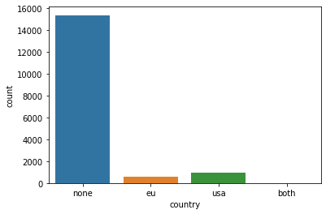

```python
# IV - categorical
sns.countplot(x='country', data=df_original)
```

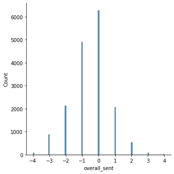

```python
# DV - continous
sns.displot(x = 'overall_sent', data = df_original)
```

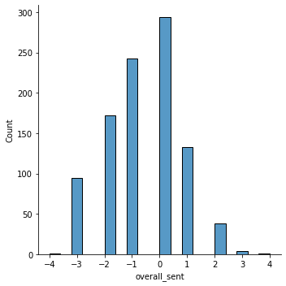

```python
sns.displot(x = 'overall_sent', data = df_original[df_original['country']== 'usa'])
```

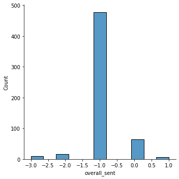

```python
sns.displot(x = 'overall_sent', data = df_original[df_original['country']== 'eu'])
```

### Bivariate visualisations

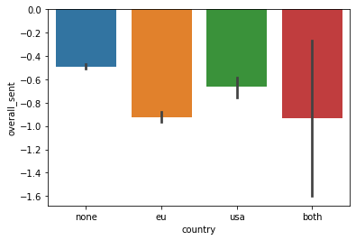

```python
# IV - categorical, DV - continous
sns.barplot(x='country', y='overall_sent', data=df_original)
```